# Using the bash shell

> **note**

> Some of the material in this tutorial was adapted from Chris Paciorek’s [2014 Statistics 243 lecture notes on Bash](https://github.com/berkeley-stat243/stat243-fall-2014/blob/master/units/unit2-bash.pdf) and his [2014 Statistics 243 lecture notes on using R](https://github.com/berkeley-stat243/stat243-fall-2014/blob/master/units/unit4-usingR.pdf).

> Before reading this, you will want to be familiar with the material in the “Basics of UNIX” tutorial and screencast here: http://statistics.berkeley.edu/computing/training/tutorials

## 1) The Interactive Shell

The shell is an interactive computer programming environment. More specifically, it is a read-evaluate-print loop (REPL) environment. R and Python also provide REPL environments. A REPL reads a single *expression* or input, parses and *evaluates* it, *prints* the results, and then *loops*.

> **note**

> I will use a `$` prompt for bash, a `>` prompt for R, a `>>>` for Python, and a `In [1]:` prompt for IPython. By convention, a regular user’s prompt in bash is `$`, while the root (or administrative) user’s prompt is `#`. However, it is common practice to never log on as the root user. If you need to run a command with root privileges, you should use the `sudo` command (see the *Getting started* section below for more details).

When you are working in a terminal window (i.e., a window with the command line interface), you’re interacting with a shell. There are multiple shells (e.g., *sh*, *bash*, *csh*, *tcsh*, *zsh*, *fish*). I’ll assume you are using *bash*, as this is the default for Mac OS X, the SCF machines, Savio, and most Linux distributions. However, the basic ideas are applicable to any Unix shell.

The shell is an amazingly powerful programming environment. From it you can interactively monitor and control almost any aspect of the OS and more importantly you can automate it. As you will see, **bash** has a very extensive set of capabilities intended to make both interactive as well as automated control simple, effective, and customizable.

> **note**

> It can be difficult to distinguish what is shell-specific and what is just part of UNIX. Some of the material here is not bash-specific but general to UNIX.

> Reference: Newham and Rosenblatt, Learning the bash Shell, 2nd ed.

### 1.1) Getting started

I assume you already have access to a basic bash shell on a computer with network access (e.g., the Terminal on a Mac, the Ubuntu subsystem on Windows, or a Linux machine). You should also have ssh installed. SSH provides an encrypted mechanism to connect to a remote Unix-based (i.e., Linux or Mac) terminal. To learn more about using ssh to connect to the SCF machines and general tips about using ssh on various operating systems, see: http://statistics.berkeley.edu/computing/ssh

To ssh to another machine, you need to know its (host)name. For example, to ssh to `arwen.berkeley.edu`, one of the SCF machines, you would:

```
$ ssh arwen.berkeley.edu
Password:
```

At this point you have to type your password. Alternatively, you can set up ssh so that you can use it without typing your password. To learn how to set this up, see: http://statistics.berkeley.edu/computing/ssh-keys

If you have a different username on SCF machines, you will need to specify it as well. For example, to specify the username `jarrod`, you would:

```
$ ssh jarrod@arwen.berkeley.edu
```

If you want to view graphical applications on your local computer that are running on the remote computer you need to use the `-X` option:

```
$ ssh -X jarrod@arwen.berkeley.edu
```

Alternatively, if you want to copy a file (`file1.txt`) from your local computer to `arwen.berkeley.edu`, you can use the `scp` command, which securely copies files between machines:

```
$ scp file1.txt jarrod@arwen.berkeley.edu:.
```

The above command will copy `file1.txt` from my current working directory on my local machine to `jarrod`’s home directory on `arwen.berkeley.edu`. The `.` following the `:` indicates that I want to copy the file to my home directory on the remote machine. I could also replace `.` with any relative path from my home directory on the remote machine or I could use an absolute path.

To copy a file (`file2.txt`) from `arwen.berkeley.edu` to my local machine:

```
$ scp jarrod@arwen.berkeley.edu:file2.txt .
```

```
$ scp jarrod@arwen.berkeley.edu:file3.txt jmillman@arwen.berkeley.edu:.
```

If instead of copying a single file, I wanted to copy an entire directory (`src`) from one machine to another, I would use the `-r` option:

```
$ scp -r src jmillman@arwen.berkeley.edu:.
```

Regardless of whether you are working on a local computer or a remote one, it is occasionally useful to operate as a different user. For instance, you may need root (or administrative) access to change file permissions or install software. (Note this will only be possible on machines that you own or have special privileges on; the Ubuntu subsystem for windows is one way to have a virtual Linux machine for which you have root access.)

For example on an Ubuntu Linux machine (including the Ubuntu subsystem for Windows), here’s how you can act as the ‘root’ user to update or add software on machines where you have administrative access:

To upgrade all the software on the machine:

```
$ sudo apt-get upgrade
```

To install the text editor vim on the machine:

```
$ sudo apt-get install vim
```

> **tip**

> Most bash commands have electronic manual pages, which are accessible directly from the commandline. You will be more efficient and effective if you become accustomed to using these `man` pages. To view the `man` page for the command `sudo`, for instance, you would type:

> ```
> $ man sudo
> ```

### 1.2) Variables

Much of how bash behaves can be customized through the use of variables, which consists of names that have values assigned to them. To access the value currently assigned to a variable, you can prepend the name with the dollar sign ($). To print the value you can use the `echo` command.

1. What is my default shell?

   `$ echo $SHELL`
2. To change to bash on a one-time basis:

   `$ bash`
3. To make it your default:

   `$ chsh /bin/bash`

In the last example, `/bin/bash` should be whatever the path to the bash shell is, which you can figure out using `which bash`.

To declare a variable, just assign a value to its reference. For example, if you want to make a new variable with the name `counter` with the value `1`:

```
$ counter=1
```

Since bash uses spaces to parse the expression you give it as input, it is important to note the lack of spaces around the equal sign. Try typing the command with and without spaces and note what happens.

You can also enclose the variable name in curly brackets, which comes in handy when you’re embedding a variable within a line of code to make sure the shell knows where the variable name ends:

```
$ base=/home/jarrod/
$ echo $basesrc
$ echo ${base}src
```

Make sure you understand the difference in behavior in the last two lines.

There are also special shell variables called environment variables that help to control the shell’s behavior. These are generally named in all caps. Type `printenv` to see them. You can create your own environment variable as follows:

```
$ export base=/home/jarrod/
```

The `export` command ensures that other shells created by the current shell (for example, to run a program) will inherit the variable. Without the export command, any shell variables that are set will only be modified within the current shell. More generally, if you want a variable to always be accessible, you should include the definition of the variable with an `export` command in your `.bashrc` file.

You can control the appearance of the bash prompt using the `PS1` variable:

```
$ echo $PS1
```

To modify it so that it puts the username, hostname, and current working directory in the prompt:

```
$ export PS1='[\u@\h \W]\$ '
[user1@local1 ~]$
```

### 1.3) Commands

While each command has its own syntax, there are some rules usually followed. Generally, a command line consists of 4 things: a command, command options, arguments, and line acceptance. Consider the following example:

```
$ ls -l file.txt
```

In the above example, `ls` is the command, `-l` is a command option specifying to use the long format, `file.txt` is the argument, and the line acceptance is indicated by hitting the `Enter` key at the end of the line.

After you type a command at the bash prompt and indicate line acceptance with the `Enter` key, bash parses the command and then attempts to execute the command. To determine what to do, bash first checks whether the command is a shell function (we will discuss functions below). If not, it checks to see whether it is a builtin. Finally, if the command is not a shell function nor a builtin, bash uses the `PATH` variable. The `PATH` variable is a list of directories:

```
$ echo $PATH
/home/jarrod/usr/bin:/usr/local/bin:/bin:/usr/bin:
```

For example, consider the following command:

```
$ grep pdf file.txt
```

We will discuss `grep` later. For now, let’s ignore what `grep` actually does and focus on what bash would do when you press enter after typing the above command. First bash checks whether `grep` a shell function or a builtin. Once it determines that `grep` is neither a shell function nor a builtin, it will look for an executable file named `grep` first in `/home/jarrod/usr/bin`, then in `/usr/local/bin`, and so on until it finds a match or runs out of places to look. You can use `which` to find out where bash would find it:

```
$ which grep
/bin/grep
```

**Exercise**

Consider the following examples using the `ls` command:

```
$ ls --all -l
$ ls -a -l
$ ls -al
```

Use `man ls` to see what the command options do. Is there any difference in what the three versions of the command invocation above return as the result? What happens if you add a filename to the end of the command?

#### 1.3.1) Tab completion

When working in the shell, it is often unnecessary to type out an entire command or file name, because of a feature known as tab completion. When you are entering a command or filename in the shell, you can, at any time, hit the tab key, and the shell will try to figure out how to complete the name of the command or filename you are typing. If there is only one command in the search path and you’re using tab completion with the first token of a line, then the shell will display its value and the cursor will be one space past the completed name. If there are multiple commands that match the partial name, the shell will display as much as it can. In this case, hitting tab twice will display a list of choices, and redisplay the partial command line for further editing. Similar behavior with regard to filenames occurs when tab completion is used on anything other than the first token of a command.

> **note**

> Note that R does tab completion for objects (including functions) and filenames. While the default Python shell does not perform tab completion, the IPython shell does.

#### 1.3.2) Command History and Editing

By using the up and down arrows, you can scroll through commands that you have entered previously. So if you want to rerun the same command, or fix a typo in a command you entered, just scroll up to it and hit enter to run it or edit the line and then hit enter.

To list the history of the commands you entered, use the `history` command:

```
$ history
  1    echo $PS1
  2    PS1=$
  3    bash
  4    export PS1=$
  5    bash
  6    echo $PATH
  7    which echo
  8    ls --all -l
  9    ls -a -l
  10   ls -al
  11   ls -al manual.xml
```

The behavior of the `history` command is controlled by a shell variables:

```
$ echo $HISTFILE
$ echo $HISTSIZE
```

You can also rerun previous commands as follows:

```
$ !-n
$ !gi
```

The first example runs the nth previous command and the second one runs the last command that started with ‘gi’.

**Table. Command History Expansion**

| Designator | Description |
| --- | --- |
| `!!` | Last command |
| `!n` | Command numbered *n* in the history |
| `!-n` | Command *n* previous |
| `!string` | Last command starting with *string* |
| `!?string` | Last command containing *string* |
| `string1string2` | Execute the previous command with *string2* substituted for *string1* |

If you’re not sure what command you’re going to recall, you can append `:p` at the end of the text you type to do the recall, and the result will be printed, but not executed. For example:

```
$ !gi:p
```

You can then use the up arrow key to bring back that statement for editing or execution.

You can also search for commands by doing `Ctrl-r` and typing a string of characters to search for in the search history. You can hit return to submit, `Ctrl-c` to get out, or `ESC` to put the result on the regular command line for editing.

#### 1.3.3) Command Substitution

You may occasionally need to substitute the results of a command for use by another command. For example, if you wanted to use the directory listing returned by `ls` as the argument to another command, you would type `$(ls)` in the location you want the result of `ls` to appear.

An older notation for command substitution is to use backticks (e.g., `` `ls` `` versus `$(ls)`). It is generally preferable to use the new notation, since there are many annoyances with the backtick notation. For example, backslashes (`\`) inside of backticks behave in a non-intuitive way, nested quoting is more cumbersome inside backticks, nested substitution is more difficult inside of backticks, and it is easy to visually mistake backticks for a single quote.

**Exercise**

Try the following commands:

```
$ ls -l tr
$ which tr
$ ls -l which tr
$ ls -l $(which tr)
```

Make sure you understand why each command behaves as it does.

### 1.4) Shortcuts

#### 1.4.1) Aliases – command shortcuts

Aliases allow you to use an abbreviation for a command, to create new functionality or to insure that certain options are always used when you call an existing command. For example, I’m lazy and would rather type `q` instead of `exit` to terminate a shell window. You could create the alias as follow:

```
$ alias q=exit
```

As another example, suppose you find the `-F` option of `ls` (which displays `/` after directories, `\` after executable files and `@` after links) to be very useful. The command :

```
$ alias ls="ls -F"
```

will insure that the `-F` option will be used whenever you use `ls`. If you need to use the unaliased version of something for which you’ve created an alias, precede the name with a backslash (`\`). For example, to use the normal version of `ls` after you’ve created the alias described above:

```
$ \ls
```

The real power of aliases is only achieved when they are automatically set up whenever you log in to the computer or open a new shell window. To achieve that goal with aliases (or any other bash shell commands), simply insert the commands in the file `.bashrc` in your home directory. For example, here is an excerpt from my `.bashrc`:

```
# .bashrc

# Source global definitions
if [ -f /etc/bashrc ]; then
        . /etc/bashrc
fi

# User specific aliases and functions
pushdp () {
 pushd "$(python -c "import os.path as _, ${1}; \
   print _.dirname(_.realpath(${1}.__file__[:-1]))"
 )"
}

export EDITOR=vim
source /usr/share/git-core/contrib/completion/git-prompt.sh
export PS1='[\u@\h \W$(__git_ps1 " (%s)")]\$ '

# history settings
export HISTCONTROL=ignoredups   # no duplicate entries
shopt -s histappend             # append, don't overwrite

# R settings
export R_LIBS=$HOME/usr/lib64/R/library
alias R="/usr/bin/R --quiet --no-save"

# Set path
mybin=$HOME/usr/bin
export PATH=$mybin:$HOME/.local/bin:$HOME/usr/local/bin:$PATH:
export LD_LIBRARY_PATH=$LD_LIBRARY_PATH:$HOME/usr/local/lib

# Additional aliases
alias grep='grep --color=auto'
alias hgrep='history | grep'
alias l.='ls -d .* --color=auto'
alias ll='ls -l --color=auto'
alias ls='ls --color=auto'
alias more=less
alias vi=vim
alias which='(alias; declare -f) | /usr/bin/which --tty-only \
         --read-alias --read-functions --show-tilde --show-dot'
```

**Exercise**

Look over the content of the example `.bashrc` and make sure you understand what each line does. For instance, use `man grep` to see what the option `--color=auto` does. Use `man which` to figure out what the various options passed to it do.

#### 1.4.2) Keyboard shortcuts

Note that you can use emacs-like control sequences (`Ctrl-a`, `Ctrl-e`, `Ctrl-k`) to navigate and delete characters.

**Table. Keyboard Shortcuts**

[output not shown]

## 2) Basic File Management

In Unix, almost “everything is a file.” This means that a very wide variety of input and output resources (e.g., documents, directories, keyboards, harddrives, network devices) are streams of bytes available through the filesystem interface. This means that the basic file management tools are extremely powerful in Unix. Not only can you use these tools to work with files, but you can also use them to monitor and control many aspects of your computer.

### 2.1) Files

A file typically consist of these attributes:

- Name.
- Type.
- Location.
- Size.
- Protection.
- Time, date, and user identification.

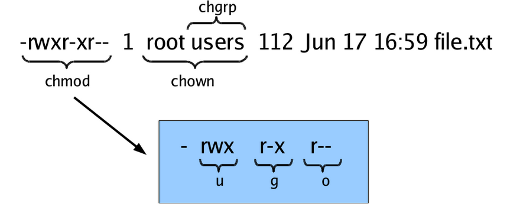

Schematic of file attributes.

Listing file attributes with `ls`:

```
$ ls -l
```

Getting more information with `stat`:

```
$ stat manual.xml
```

Finding out what type of file you have:

```
$ file manual.xml
```

> **tip**

> **The `file` command relies on many sources**

> of information to determine what a file contains. The easiest part to explain is *magic*. Specifically, the `file` command examines the content of the file and compares it with information found in the `/usr/share/magic/` directory.

> Changing file attributes with `chmod`:

```
$ chmod g+w manual.xml
```

For more detailed information, please see the “Basics of UNIX” tutorial and screencast here: http://statistics.berkeley.edu/computing/training/tutorials

### 2.2) Navigation

Efficient navigation of the filesystem from the shell is an essential aspect of mastering Unix. Use `pwd` to list your current working directory. If you just enter `cd` at a prompt, your current working directory will change to your home directory. You can also refer to your home directory using the tilde `~`. For example, if you wanted to change your current directory to the subdirectory `src` in your home directory from any other current directory, you could type:

```
$ cd ~/src
```

Also if you want to return to the previous directory, you could type:

```
$ cd -
```

You can use the pushd, popd, and dirs commands if you would like to keep a stack of previous working directories rather than just the last one.

### 2.3) Filename Globbing

Shell file globbing will expand certain special characters (called wildcards) to match patterns of filenames, before passing those filenames on to a program. Note that the programs themselves don’t know anything about wildcards; it is the shell that does the expansion, so that programs don’t see the wildcards. The following table shows some of the special characters that the shell uses for expansion.

**Table. Filename wildcards**

| Wildcard | Function |
| --- | --- |
| `*` | Match zero or more characters. |
| `?` | Match exactly one character. |
| `[characters]` | Match any single character from among *characters* listed between brackets. |
| `[!characters]` | Match any single character other than *characters* listed between brackets. |
| `[a-z]` | Match any single character from among the range of characters listed between brackets. |
| `[!a-z]` | Match any single character from among the characters not in the range listed between brackets |
| `{frag1,frag2,…}` | Brace expansion: create strings frag1, frag2, etc. |

List all files ending with a digit:

```
$ ls *[0-9]
```

Make a copy of `filename` as `filename.old`:

```
$ cp filename{,.old}
```

Remove all files beginning with *a* or *z*:

```
$ rm [az]*
```

List all the R code files with a variety of suffixes:

```
$ ls *.{r,q,R}
```

The `echo` command can be used to verify that a wildcard expansion will do what you think it will:

```
$ echo cp filename{,.old}
cp filename filename.old
```

If you want to suppress the special meaning of a wildcard in a shell command, precede it with a backslash (`\`). Note that this is a general rule of thumb in many similar situations when a character has a special meaning but you just want to treat it as a character.

To read more about standard globbing patterns, see the man page:

```
$ man 7 glob
```

**Exercise**

Brace expansion is quite useful and more flexible than I’ve indicated. Above we saw how to use brace expansion using a comma comma separated list of items inside the curly braces (e.g., `{r,q,R}`), but they can also be used with a sequence specification. A sequence is indicated with a start and end item separated by two periods (`..`). Try typing the following examples at the command line and try to figure out how they work:

```
$ echo {1..15}
$ echo {a{1..3},b{1..5},c{c..e}}
$ echo {{d..a},{a..d}}
$ echo {{d..b},a,{b..d}}
$ echo {1..5..2}
$ echo {z..a..-2}
```

### 2.4) Quoting

Finally, a note about using single vs. double quotes in shell code. In general, variables inside double quotes will be evaluated, but variables not inside double quotes will not be:

```
$ echo "$HOME"
/home/jarrod
$ echo '$HOME'
$HOME
```

**Table. Quotes**

| Types of Quoting | Description |
| --- | --- |
| `‘’` | hard quote - no substitution allowed |
| `" “` | soft quote - allow substitution |

This can be useful, for example, when you have a directory with a space in its name (of course, it is better to avoid spaces in file and directory names). Since bash uses spaces to parse the elements of the command line, you might try escaping the spaces with a backslash:

```
$ ls $HOME/with\ space
file1.txt
```

However that can be a pain and may not work in all circumstances. A cleaner approach is to use soft (or double) quotes:

```
$ ls "$HOME/with space"
file1.txt
```

If you used hard quotes, you will get this error:

```
$ ls '$HOME/with space'
ls: cannot access $HOME/with space: No such file or directory
```

What if you have double quotes in your file or directory name (again, it is better to avoid using double quotes in file and directory names)? In this case, you will need to escape the quote:

```
$ ls "$HOME/\"with\"quote"
```

So we’ll generally use double quotes. We can always work with a literal double quote by escaping it as seen above.

### 2.5) Basic utilities

Since files are such an essential aspect of Unix and working from the shell is the primary way to work with Unix, there are a large number of useful commands and tools to view and manipulate files.

- cat – concatenate files and print on the standard output
- cp – copy files and directories
- cut –_remove sections from each line of files
- diff– find differences between two files
- grep – print lines matching a pattern
- head – output the first part of files
- find – search for files in a directory hierarchy
- less – opposite of more (and better than more)
- more – file perusal filter for crt viewing
- mv – move (rename) files
- nl – number lines of files
- paste – merge lines of files
- rm – remove files or directories
- rmdir – remove empty directories
- sort – sort lines of text files.
- split – split a file into pieces
- tac – concatenate and print files in reverse
- tail – output the last part of files
- touch – change file timestamps
- tr – translate or delete characters
- uniq – remove duplicate lines from a sorted file
- wc – print the number of bytes, words, and lines in files
- wget and curl – non-interactive network downloader

As we’ve already seen the general syntax for a Unix program is:

```
$ command -options argument1 argument2 ...
```

For example, :

```
$ grep -i graphics file.txt
```

looks for the literal string `graphics` (argument 1) in `file.txt` (argument2) with the option `-i`, which says to ignore the case of the letters. While :

```
$ less file.txt
```

simply pages through a text file (you can navigate up and down) so you can get a feel for what’s in it. To exit `less` type `q`.

To find files by name, modification time, and type:

```
$ find . -name '*.txt'  # find files named *.txt
$ find . -mtime -2      # find files modified less than 2 days ago
$ find . -type l        # find links
```

Unix programs often take options that are identified with a minus followed by a letter, followed by the specific option (adding a space before the specific option is fine). Options may also involve two dashes, e.g., `R --no-save`. A standard two dash option for many commands is `--help`. For example, try:

```
$ tail --help
```

Here are a couple of examples of using the `tail` command:

```
$ wget https://raw.githubusercontent.com/berkeley-scf/tutorial-using-bash/master/cpds.csv
$ tail -n 10 cpds.csv   # last 10 lines of cpds.csv
$ tail -f cpds.csv      # shows end of file, continually refreshing
```

The first line downloads the data from GitHub. The two main tools for downloading network accessible data from the commandline are `wget` and `curl`. I tend to use `wget` as my commandline downloading tool as it is more convenient, but on a Mac, only `curl` is generally available.

A few more tidbits about `grep` (we will see more examples of `grep` in the section on regular expressions, but it is so useful that it is worth seeing many times):

```
$ grep ^2001 cpds.csv   # returns lines that start with '2001'
$ grep 0$ cpds.csv      # returns lines that end with '0'
$ grep 19.0 cpds.csv    # returns lines with '19' separated from '0' by a single character
$ grep 19.*0 cpds.csv   # now separated by any number of characters
$ grep -o 19.0 cpds.csv # returns only the content matching the pattern from the relevant lines
```

Note that the first argument to grep is the pattern you are looking for. The syntax is different from that used for wildcards in file names. Also, you can use regular expressions in the pattern. We won’t see this in detail here, but we will discuss this in the section below on regular expressions.

It is sometimes helpful to put the pattern inside double quotes, e.g., if you want spaces in your pattern:

```
$ grep "George .* Bush" cpds.csv
```

More generally in Unix, enclosing a string in quotes is often useful to indicate that it is a single argument/value.

If you want to explicitly look for one of the special characters used in creating patterns (such as double quote (`"`), period (`.`), etc., you can “escape” them by preceding with a back-slash. For example to look for `"Canada"`, including the quotes:

```
$ grep "\"Canada\"" cpds.csv
$ grep "19\.0" cpds.csv
```

If you have a big data file and need to subset it by line (e.g., with `grep`) or by field (e.g., with `cut`), then you can do it really fast from the Unix command line, rather than reading it with R, SAS, Python, etc.

Much of the power of these utilities comes in piping between them (see the next section) and using wildcards (see the section on Globbing) to operate on groups of files. The utilities can also be used in shell scripts to do more complicated things.

We will look at several examples of how to use these utilities below, but first let’s discuss streams and redirection.

### 2.6) Streams, Pipes, and Redirects

Unix programs that involve input and/or output often operate by reading input from a stream known as standard input (*stdin*), and writing their results to a stream known as standard output (*stdout*). In addition, a third stream known as standard error (*stderr*) receives error messages and other information that’s not part of the program’s results. In the usual interactive session, standard output and standard error default to your screen, and standard input defaults to your keyboard.

You can change the place from which programs read and write through redirection. The shell provides this service, not the individual programs, so redirection will work for all programs. The following table shows some examples of redirection.

**Table. Common Redirection Operators**

| Redirection Syntax | Function |
| --- | --- |
| `$ cmd > file` | Send *stdout* to *file* |
| `$ cmd 1> file` | Same as above |
| `$ cmd 2> file` | Send *stderr* to *file* |
| `$ cmd > file 2>&1` | Send both *stdout* and *stderr* to *file* |
| `$ cmd < file` | Receive *stdin* from *file* |
| `$ cmd >> file` | Append *stdout* to *file*: |
| `$ cmd 1>> file` | Same as above |
| `$ cmd 2>> file` | Append *stderr* to *file* |
| `$ cmd >> file 2>&1` | Append both *stdout* and *stderr* to *file* |
| `$ cmd1 \| cmd2` | Pipe *stdout* from *cmd1* to *cmd2* |
| `$ cmd1 2>&1 \| cmd2` | Pipe *stdout* and *stderr* from *cmd1* to *cmd2* |
| `$ cmd1 \| tee file1 \| cmd2` | Pipe *stdout* from *cmd1* to *cmd2* while simultaneously writing it to *file1* |
|  | using *tee* |

Note that `cmd` may include options and arguments as seen in the previous section.

#### 2.6.1) Standard Redirection

Operations where output from one command is used as input to another command (via the `|` operator) are known as pipes; they are made especially useful by the convention that many UNIX commands will accept their input through the standard input stream when no file name is provided to them.

A simple pipe to `wc` to count the number of words in a string:

```
$ echo "hey there" | wc -w
2
```

Translating lowercase to UPPERCASE with `tr`:

```
$ echo 'user1'  | tr 'a-z' 'A-Z'
USER1
```

Here’s an example of finding out how many unique entries there are in the 2nd column of a data file whose fields are separated by commas:

```
$ cut -d',' -f2 cpds.csv | sort | uniq | wc
$ cut -d',' -f2 cpds.csv | sort | uniq > countries.txt
```

Above we use the `cut` utility to extract the second field (`-f2`) or column of the file `cpds.csv` where the fields (or columns) are split or delimited by a comma (`-d','`). The standard output of the `cut` command is then piped (via `|`) to the standard input of the `sort` command. Then the output of `sort` is sent to the input of `uniq` to remove duplicate entries in the sorted list provided by `sort`. Rather than using `sort | uniq`, you could also use `sort -u`. Finally, the first of the `cut` commands prints a word count summary using `wc`; while the second saving the sorted information with duplicates removed in the file `countries.txt`.

To see if there are any “S” values in certain fields (fixed width) of a set of files (note I did this on 22,000 files (5 Gb or so) in about 5 minutes on my desktop; it would have taken much more time to read the data into R):

```
$ cut -b29,37,45,53,61,69,77,85,93,101,109,117,125,133,141,149, \
        157,165,173,181,189,197,205,213,221,229,237,245,253, \
        261,269 USC*.dly | grep S | less
```

A closely related, but subtly different, capability that we saw above is command substitution. Recall that when the shell encounters a command surrounded by `$()` (or backticks), it runs the command and replaces the expression with the output from the command; this allows something similar to a pipe, but is appropriate when a command reads its arguments directly from the command line instead of through standard input. For example, suppose we are interested in searching for the text `pdf` in the last 4 R code files (those with suffix `.r` or `.R`) that were modified in the current directory. We can find the names of the four most recently modified files ending in `.R` or `.r` using:

```
$ ls -t *.{R,r} | head -4
```

```
$ grep pdf $(ls -t *.{R,r} | head -4)
```

Note that piping the output of the `ls` command into `grep` would not achieve the desired goal, since `grep` reads its filenames from the command line, not standard input.

#### 2.6.2) The `xargs` and `tee` commands

You can also redirect output as the arguments to another program using the `xargs` utility. Here’s an example:

```
$ ls -t *.{R,r} | head -4 | xargs grep pdf
```

The `tee` command lets you create two streams from one. For example, consider the case where you want the results of this command:

```
$ cut -d',' -f2 cpds.csv | sort | uniq
```

to both be output to the terminal screen you are working in as well as being saved to a file. You could issue the command twice:

```
$ cut -d',' -f2 cpds.csv | sort | uniq
$ cut -d',' -f2 cpds.csv | sort | uniq > countries.txt
```

Instead of repeating the command and wasting computing time, you could use `tee` command:

```
$ cut -d',' -f2 cpds.csv | sort | uniq | tee countries.txt
```

## 3) Regular Expressions

Regular expressions (regex) are a domain-specific language for finding patterns and are one of the key functionalities in scripting languages such as Perl and Python, as well as the UNIX utilities `sed`, `awk`, and `grep` as we will see below. I’ll just cover the basic use of regular expressions in bash, but once you know that, it would be easy to use them elsewhere (Python, R, etc.). At the level we’ll consider them, the syntax is quite similar.

> **note**

> POSIX.2 regular expressions come in two flavors: extended regular expressions and basic (or obsolete) regular expressions. The extended syntax has metacharacters `()` and `{}`, while the basic syntax requires the metacharacters to be designated `\(\)` and `\{\}`. In addition to the POSIX standard, Perl regular expressions are also widely used. While we won’t go into detail, we will see some examples of each syntax. In the examples that follow we’ll generally use the extended syntax by using the `-E` flag to `grep`.

### 3.1) Overview and core syntax

The basic idea of regular expressions is that they allow us to find matches of strings or patterns in strings, as well as do substitution. Regular expressions are good for tasks such as:

- extracting pieces of text - for example finding all the links in an html document;
- creating variables from information found in text;
- cleaning and transforming text into a uniform format;
- mining text by treating documents as data; and
- scraping the web for data.

Regular expressions are constructed from three things:

1. *Literal characters* are matched only by the characters themselves,
2. *Character classes* are matched by any single member in the class, and
3. *Modifiers* operate on either of the above or combinations of them.

Note that the syntax is very concise, so it’s helpful to break down individual regular expressions into the component parts to understand them. Since regex are their own language, it’s a good idea to build up a regex in pieces as a way of avoiding errors just as we would with any computer code. It is also helpful to search for common regex online before trying to craft your own. For instance, if you wanted to use a regex that matches valid email addresses, you would need to match anything that complies with the [RFC 822](http://www.ietf.org/rfc/rfc0822.txt?number=822) grammar. If you look over that document, you will quickly realize that implementing a correct regular expression to validate email addresses is extremely complex. So if you are writing a website that validates email addresses, it is best to look for a bug-vetted implementation rather than creating your own.

The special characters (meta-characters) used for defining regular expressions are:

```
* . ^ $ + ? ( ) [ ] { } | \
```

To use these characters literally as characters, we have to ‘escape’ them. In bash, you escape these characters by placing a single backslash before the character you want to escape. In R, we have to use two backslashes instead of a single backslash because R uses a single backslash to symbolize certain control characters, such as `\n` for newline.

### 3.2) Character sets and character classes

**Character sets**

[output not shown]

If we want to search for any one of a set of characters, we use a character set, such as `[13579]` or `[abcd]` or `[0-9]` (where the dash indicates a sequence) or `[0-9a-z]`. To indicate any character not in a set, we place a `^` just inside the first bracket: `[^abcd]`.

```
$ grep -E -o [0-9] test.txt
```

There are a bunch of named character classes so that we don’t have write out common sets of characters. The syntax is `[:CLASS:]` where `CLASS` is one of the following values:

```
"alnum", "alpha", "ascii", "blank", "cntrl", "digit", "graph",
"lower", "print", "punct", "space", "upper", "word" or "xdigit".

$ grep -E -o [[:punct:]] test.txt
```

To learn more about regular expressions, you can type:

```
$ man 7 regex
```

To make a character set with a character class you need two square brackets, e.g. the digit class: `[[:digit:]]`. Or we can make a combined character set such as `[[:alnum:]_]` (to find any alphabetic or numeric characters or an underscore).

```
$ grep -E -o [[:digit:]\.\,] test.txt
```

### 3.3) Location-specific matches

**Position anchors**

| Operators | Description |
| --- | --- |
| `^` | Match the beginning of a line. |
| `$` | Match the end of a line. |

To find a pattern at the beginning of the string, we use `^` (note this was also used for negation, but in that case occurs only inside square brackets) and to find it at the end we use `$`.

```
$ grep -E -o ^[0-9] test.txt
$ grep -E -o [0-9]$ test.txt
```

### 3.4) Repetitions, Grouping, and References

Now suppose I wanted to be able to detect phone numbers, email addresses, etc. I often need to be able to deal with repetitions of character sets.

**Modifiers**

| Operators | Description |
| --- | --- |
| `*` | Match zero or more instances of the preceding character or *regex*. |
| `?` | Match zero or one instance of the preceding character or *regex*. |
| `+` | Match one or more instances of the preceding character or *regex*. |
| `{n,m}` | Match a range of occurrences of the single character or *regex* that precedes this construct. |
| `\|` | Match the character or expression to the left or right of the vertical bar. |

I can indicate repetitions as indicated in these examples:

- `[[:digit:]]*` – any number of digits (zero or more)
- `[[:digit:]]+` – at least one digit
- `[[:digit:]]?` – zero or one digits
- `[[:digit:]]{1,3}` – at least one and no more than three digits
- `[[:digit:]]{2,}` – two or more digits

  $ grep -E -o [0-9]+ test.txt

An example is that `\[.*\]` is the pattern of closed square brackets with any number of characters (`.*`) inside.

We often want to be able to look for multi-character patterns. For example, if you wanted to match phone numbers whether they start with `1-` or not you could use the following:

```
(1-)?[[:digit:]]{3}-[[:digit:]]{3}-[[:digit:]]{4}
```

The first part of the pattern `(1-)?` matches 0 or 1 occurrences of `1-`. Then the pattern `[[:digit:]]{3}` matches any 3 digits. Similarly, the pattern `[[:digit:]]{4}` matches any 4 digits. So the whole pattern matches any three digits followed by `-`, then another three digits, and then followed by four digits when it is preceded by 0 or 1 occurrences of `1-`.

Parentheses are also used with a pipe (`|`) to indicate any one of a set of multi-character sequences, such as `(http|ftp)`. Here we need double quotes or the shell tries to interpret the `(`.

```
$ grep -E -o "(http|ftp)" test.txt
```

### 3.5) Greedy matching

Regular expression pattern matching is *greedy*—by default, the longest matching string is chosen.

Suppose we have the following file:

```
$ cat file1.txt
Do an internship <b> in place </b> of <b> one </b> course.
```

If we want to match the html tags (e.g., `<b>` and `</b>`, we might be tempted to use the pattern `<.*>`. Using the `-o` option to grep, we can have grep print out just the part of the text that the pattern matches:

```
$ grep -o "<.*>" file1.txt
<b> in place </b> of <b> one </b>
```

To get a non-greedy match, you can use the modifier `?` after the quantifier. However, this requires that we use the Perl syntax. In order for grep to use the Perl syntax, we need to use the `-P` option:

```
$ grep -P -o "<.*?>" file1.txt
<b>
</b>
<b>
</b>
```

However, one can often avoid greedy matching by being more clever.

**Challenge**: How could we change our regexp to avoid the greedy matching without using the `?` modifier? Hint: Is there some character set that we don’t want to be inside the angle brackets?

> **tip**

> **Globs vs. Regex:**

> ```
> Be sure you understand the difference between filename globbing
> (see the Section called *Filename Globbing*) and regular
> expressions. Filename globbing only works for filenames, while
> regular expressions are used to match patterns in text more
> generally. While they both use the same set of symbols, they mean
> different things (e.g., `*` matches 0 or more characters when
> globbing but matches 0 or more repetitions of the character that
> precedes it when used in a regular expression).
> ```

### 3.6) `ed`, `grep`, `sed`, `awk`, and `perl`

Before the text editor, there was the line editor. Rather than presenting you with the entire text as a text editor does, a line editor only displays lines of text when it is requested to. The original Unix line editor is called `ed`. You will likely never use `ed` directly, but you will very likely use commands that are its descendants. For example, the commands `grep`, `sed`, `awk`, and `vim` are all based directly on `ed` (e.g., `grep` is a `ed` command that is now available as a standalone command, while `sed` is a streaming version of `ed`) or inherit much of its syntax (e.g., `awk` and `vim` both heavily borrow from the `ed` syntax). Since `ed` was written when computing resources were very constrained compared to today, this means that the syntax of these commands can be terse. However, it also means that learning the syntax for one of these tools will be rewarded when you need to learn the syntax of another of these tools.

#### 3.6.1) `grep`

The simplest of these tools is `grep`. As I mentioned, `ed` only displays lines of text when requested. One common task was to print all the lines in a file matching a specific regular expression. The command in `ed` that does this is `g/<re>/p`, which stands for globally match all lines containing the regular express `<re>` and print them out.

To start you will need to create a file called `file1.txt` with the following content:

```
This is the first line.
Followed by this line.
And then ...
```

To print all the lines containing `is`:

```
$ grep is file1.txt
This is the first line.
Followed by this line.
```

To print all the lines **not** containing `is`:

```
$ grep -v is file1.txt
And then ...
```

Now let’s consider a file named `file2.txt` with the following content:

```
Here's my number: 919-543-3300.
hi John, good to meet you
They bought 731 bananas
Please call 1.919.554.3800
I think he said it was 337.4355
```

```
$ grep  '(1-)?[[:digit:]]{3}-[[:digit:]]{4}' file2.txt
```

```
$ grep -E '(1-)?[[:digit:]]{3}-[[:digit:]]{4}' file2.txt
Here's my number: 919-543-3300.
```

or use the `egrep` command:

```
$ egrep  '(1-)?[[:digit:]]{3}-[[:digit:]]{4}' file2.txt
Here's my number: 919-543-3300.
```

If we want to match regardless of whether the phone number is separated by a minus `-` or a period `.`, we could use the pattern `[-.]`:

```
$ egrep  '(1[-.])?[[:digit:]]{3}[-.][[:digit:]]{4}' file2.txt
Here's my number: 919-543-3300.
Please call 1.919.554.3800
I think he said it was 337.4355
```

**Exercise**

Explain what the following regular expression matches:

```
$ grep '^[^T]*is.*$' file1.txt
```

#### 3.6.2) `sed` and `awk`

Printing lines of text with `sed`:

```
$ sed -n '1,9p' file.txt       # prints out lines 1-9 of file.txt
$ sed -n '/^#/p' file.txt       # prints out lines starting with # of file.txt
```

The first command prints out lines 1-9 of `file.txt`, while the second one prints out lines starting with `#` of `file.txt`.

Deleting lines of text with `sed`:

```
$ sed -e '1,9d' file.txt
$ sed -e '/^;/d' -e '/^$/d' file.txt
```

The first line deletes lines 1-9 of `file.txt`. What do you think the second line does?

Note that the -e flag is only necessary if you want to have more than one expression, so it’s not actually needed in the first line.

Text substitution with `sed`:

```
$ sed 's/old_pattern/new_pattern/' file.txt > new_file.txt
$ sed 's/old_pattern/new_pattern/g' file.txt > new_file.txt
$ sed -i 's/old_pattern/new_pattern/g' file.txt
```

The first line replaces only the first instance in a line, while the second line replaces all instances in a line (i.e., globally). The use of the -i flag in the third line replaces the pattern in place in the file, thereby altering file.txt.

Awk is a general purpose programming language typically used in data extraction tasks and particularly well-suited to one-liners (although it is possible to write long programs in it, it is rare). For our purposes, we will just look at a few common one-liners to get a sense of how it works. Basically, awk will go through a file line by line and perform some action for each line.

For example to double space a file, you would read each line, print it, and then print a blank line:

```
$ awk '{ print } { print "" }' file.txt
```

Print every line of a file that is longer than 80 characters:

```
$ awk 'length($0) > 80' file.txt
```

Print the home directory of every user defined in the file `/etc/passwd`:

```
$ awk -F: '{ print $6 }' /etc/passwd
```

To see what this did, let’s look at the first line of `/etc/passwd`:

```
$ head -n 1 /etc/passwd
root:x:0:0:root:/root:/bin/bash
```

As you can see the entries are separated by colons (`:`) and the sixth field contains the root user’s home directory (`/root`). The option `-F:` specifies that the colon `:` is the field delimiter and `print $6` prints the 6th field of each line.

You don’t need to know much `sed` or `awk`, but it is good to know about them since you can search the internet for awk or sed one-liners. If you have some file munging task, it can be helpful to do a quick search before writing code to perform the task yourself.

#### 3.6.3) `perl`

Perl is another general-purpose programming language that is particular useful for one-liner commands to perform data extraction and manipulation tasks. Again even if you don’t learn how to program in Perl, it can be useful to have a couple one-liners in your toolbox.

Text substitution with `perl`:

```
$ perl -pi -e 's/old_pattern/new_pattern/g' file.txt
$ perl -pi -e 's/old_pattern/new_pattern/g' $(find . -name \*.html)
```

The `i` option tells `perl` to do the global substitution in place. You can also substitute the `/` with another character. For example:

```
$ perl -pi -e 's:old_pattern:new_pattern:g' file.txt
```

Summing columns with `perl`:

```
$ perl -lane 'print $F[0] + $F[1]' file.txt
```

This will sum columns 1 and 2 of `file.txt`.

## 4) Processes

A process is a program that is being executed. Processes have the following attributes:

- A lifetime.
- A process ID (PID).
- A user ID (UID).
- A group ID (GID).
- A parent process.
- An environment.
- A current working directory.

### 4.1) Monitoring

Examining subprocesses of your shell with `ps`:

```
$ ps
PID TTY          TIME CMD
19370 pts/3    00:00:00 bash
22846 pts/3    00:00:00 ps
```

Examining in more detail subprocesses of your shell with `ps`:

```
$ ps -f
UID        PID  PPID  C STIME TTY          TIME CMD
jarrod   19370 19368  0 10:51 pts/3    00:00:00 bash
jarrod   22850 19370  0 14:57 pts/3    00:00:00 ps -f
```

Examining in more detail all processes on your computer:

```
$ ps -ef
UID        PID  PPID  C STIME TTY          TIME CMD
root         1     0  0 Aug21 ?        00:00:05 /usr/lib/systemd
root         2     0  0 Aug21 ?        00:00:00 [kthreadd]
root         3     2  0 Aug21 ?        00:00:07 [ksoftirqd/0]
root         5     2  0 Aug21 ?        00:00:00 [kworker/0:0H]
   <snip>
root     16210     1  0 07:19 ?        00:00:00 login -- jarrod
jarrod   16219 16210  0 07:19 tty1     00:00:00 -bash
jarrod   16361 16219  0 07:19 tty1     00:00:00 /bin/sh /bin/startx
   <snip>
```

You can use the `-u` option to see percent CPU and percent memory used by each process. You can use the `-o` option to provide your own user-defined format; for example, :

```
$ ps -o pid,ni,pcpu,pmem,user,comm
  PID  NI %CPU %MEM USER     COMMAND
18124   0  0.0  0.0 jarrod   bash
22963   0  0.0  0.0 jarrod   ps
```

To see the hierarchical process structure, you can use the `pstree` command.

Examining processes with `top`:

```
$ top
top - 13:49:07 up  1:49,  3 users,  load average: 0.10, 0.15, 0.18
Tasks: 160 total,   1 running, 158 sleeping,   1 stopped,   0 zombie
%Cpu(s):  2.5 us, 0.5 sy, 0.0 ni, 96.9 id, 0.0 wa, 0.0 hi, 0.0 si, 0.0 st
KiB Mem : 7893644 total, 5951552 free, 1085584 used,  856508 buff/cache
KiB Swap: 7897084 total, 7897084 free,       0 used. 6561548 avail Mem

  PID USER     PR  NI    VIRT    RES    SHR S  %CPU %MEM     TIME+ COMMAND
 1607 jarrod   20   0 2333568 974888 212944 S  12.5 12.4  11:10.67 firefox
 3366 jarrod   20   0  159828   4312   3624 R   6.2  0.1   0:00.01 top
    1 root     20   0  193892   8484   5636 S   0.0  0.1   0:01.78 systemd
```

To quit `top`, type `q`.

### 4.2) Signaling

Let’s see how to build up a command to kill firefox using some of the tools we’ve seen. First let’s pipe the output of `ps -e` to `grep` to select the line corresponding to `firefox`:

```
$ ps -e | grep firefox
16517 ?        00:10:03 firefox
```

We can now use `awk` to select the first column, which contains the process ID corresponding to `firefox`:

```
$ ps -e | grep firefox | awk '{ print $1 }'
16517
```

Finally, we can pipe this to the `kill` command using `xargs`:

```
$ ps -e | grep firefox | awk '{ print $1 }' | xargs kill
```

### 4.3) Job Control

When you run a command in a shell by simply typing its name, you are said to be running in the foreground. When a job is running in the foreground, you can’t type additional commands into that shell session, but there are two signals that can be sent to the running job through the keyboard. To interrupt a program running in the foreground, use `Ctrl-c`; to quit a program, use `Ctrl-\`. While modern windowed systems have lessened the inconvenience of tying up a shell with foreground processes, there are some situations where running in the foreground is not adequate.

The primary need for an alternative to foreground processing arises when you wish to have jobs continue to run after you log off the computer. In cases like this you can run a program in the background by simply terminating the command with an ampersand (`&`). However, before putting a job in the background, you should consider how you will access its results, since *stdout* is not preserved when you log off from the computer. Thus, redirection (including redirection of *stderr*) is essential when running jobs in the background. As a simple example, suppose that you wish to run an R script, and you don’t want it to terminate when you log off. (Note that this can also be done using `R CMD BATCH`, so this is primarily an illustration.)

```
$ R --no-save < code.R > code.Rout 2>&1 &
```

If you forget to put a job in the background when you first execute it, you can do it while it’s running in the foreground in two steps. First, suspend the job using the `Ctrl-z` signal. After receiving the signal, the program will interrupt execution, but will still have access to all files and other resources. Next, issue the `bg` command, which will start the stopped job running in the background.

#### 4.3.1) Listing and killing jobs

Since only foreground jobs will accept signals through the keyboard, if you want to terminate a background job you must first determine the unique process id (PID) for the process you wish to terminate through the use of the `ps` command.

To see all processes owned by a specific user (e.g., `jarrod`), I can use the `-U jarrod` option:

```
$ ps -U jarrod
```

If I want to get more information (e.g., `%CPU` and `%MEM`), I can use add the `-u` option:

```
$ ps -U jarrod -u
USER       PID %CPU %MEM    VSZ   RSS TTY      STAT START    TIME COMMAND
jarrod   16116 12.0  6.0 118804  5080 tty1     Ss   16:25  133:01 python
```

```
$ kill 11998
```

or, if that doesn’t work:

```
$ kill -9 11998
```

to terminate the job. Another useful command in this regard is `killall`, which accepts a program name instead of a process id, and will kill all instances of the named program:

```
$ killall R
```

Of course, it will only kill the jobs that belong to you, so it will not affect the jobs of other users. Note that the `ps` and `kill` commands only apply to the particular computer on which they are executed, not to the entire computer network. Thus, if you start a job on one machine, you must log back into that same machine in order to manage your job.

#### 4.3.2) Monitoring jobs and memory use

As we saw above, the `top` command also allows you to monitor the jobs on the system and in real-time. In particular, it’s useful for seeing how much of the CPU and how much memory is being used, as well as figuring out a PID as an alternative to `ps`. You can also renice jobs (see below) and kill jobs from within top: just type `r` or `k`, respectively, and proceed from there.

One of the main things to watch out for is a job that is using close to 100% of memory and much less than 100% of CPU. What is generally happening is that your program has run out of memory and is using virtual memory on disk, spending most of its time writing to/from disk, sometimes called *paging* or *swapping*. If this happens, it can be a very long time, if ever, before your job finishes.

#### 4.3.3) Nicing a job

The most important thing to remember when starting a job on a machine that is not your personal machine is how to be a good citizen. This often involves ‘nicing’ your jobs. Nicing a job puts it at a lower priority so that a user working at the keyboard has higher priority in using the CPU. Here’s how to do it, giving the job a low priority of 19:

```
$ nice -19 R CMD BATCH --no-save code.R code.Rout &
```

If you forget and just submit the job without nicing, you can reduce the priority by doing:

```
$ renice +19 11998
```

where `11998` is the PID of your job.

#### 4.3.4) Screen

Screen allows you to create virtual terminals, which are not connected to your actual terminal or shell. This allows you to run multiple programs from the commandline and leave them all in the foreground in their own virtual terminal. Screen provides facilities for managing several virtual terminals including listing them, switching between them, disconnecting from one machine and then reconnecting from another. While we will only discuss its basic operation, we will cover enough to be of regular use.

Calling screen :

```
$ screen
```

will open a single window and you will see a new bash prompt. You just work at this prompt as you normally would. The difference is that you can disconnect from this window by typing `Ctrl-a d` and you will see something like this :

```
$ screen
[detached from 23974.pts-2.t430u]
```

> **tip**

> All the screen key commands begin with the control key combination `Ctrl-a` followed by another key. For instance, when you are in a screen session and type `Ctrl-a ?`, screen will display a help screen with a list of its keybindings.

You can now list your screen sessions :

```
$ screen -ls
There is a screen on:
        23974.pts-2.t430u       (Detached)
```

To reconnect :

```
$ screen -r
```

You can start multiple screen sessions. This is what it might look like if you have 3 screen sessions:

```
$ screen -ls
There are screens on:
        24274.pts-2.t430u       (Attached)
        24216.pts-2.t430u       (Detached)
        24158.pts-2.t430u       (Detached)
```

To specify that you want to reattach to session `24158.pts-2.t430u`, type:

```
$ screen -r 24158.pts-2.t430u
```

If you have several screen sessions, you will want to name your screen session something more informative than `24158.pts-2.t430u`. To name a screen session `gene-analysis` you can use the `-S` option when calling screen:

```
$ screen -S gene-analysis
```

While there are many more features and keybindings available for screen, you’ve already seen enough screen to be useful. For example, imagine you ssh to a remote machine from your laptop to run an analysis. The first thing you do at the bash prompt on the remote machine is:

```
$ screen -S dbox-study
```

Then you start your analysis script `dbox-analysis.py` running:

```
$ dbox-analysis.py
Starting statistical analysis ...
Processing subject 1 ...
Processing subject 2 ...
```

If your study has 50 subjects and processing each subject takes 20 minutes, you will not want to sit there watching your monitor. So you use `Ctrl-a d` to detach the session and you will then see:

```
$ screen -S dbox-study
[detached from 2799.dbox-study]
$
```

Now you can log off your laptop and go home. Sometime after dinner, you decide to check on your job. So you ssh from your home computer to the remote machine again and type the following at the bash prompt:

```
$ screen -r dbox-study
```

## 5) Shell programming

Shell scripts are files containing shell commands (commonly with the extension `.sh`) To run a shell script called `file.sh`, you would type :

```
$ source ./file.sh
```

or :

```
$ . ./file.sh
```

Note that if you just typed `file.sh`, the operating system will generally have trouble finding the script and recognizing that it is executable. To be sure that the operating system knows what shell to use to interpret the script, the first line of the script should be `#!/bin/bash` (in the case that you’re using the bash shell). Also, if you set `file.sh` to be executable (i.e., to have the ‘x’ flag set) you can execute it by just typing `./file.sh`.

### 5.1) Functions

You can define your own utilities by creating a shell function. This allows you to automate things that are more complicated than you can do with an alias. One nice thing about shell functions is that the shell automatically takes care of function arguments for you. It places the arguments given by the user into local variables in the function called (in order): `$1 $2 $3` etc. It also fills `$#` with the number of arguments given by the user. Here’s an example of using arguments in a function that saves me some typing when I want to copy a file to the SCF filesystem:

```
function putscf() {
   scp $1 jarrod@scf-ug02.berkeley.edu:$2
}
```

To use this function, I just do the following to copy `unit1.pdf` from the current directory on whatever non-SCF machine I’m on to the directory `~/teaching/243` on SCF:

```
$ putscf unit1.pdf ~/teaching/243/.
```

Of course you’d want to put such functions in your `.bashrc` file.

### 5.2) If/then/else

We can use if-then-else type syntax to control the flow of a shell script. For an example, here is a shell function `niceR()` that can be used for nicing R jobs:

```
# niceR shortcut for nicing R jobs
# usage: niceR inputRfile outputRfile
# Author: Brian Caffo
# Date: 10/01/03

function niceR(){
    # submits nice'd R jobs
    if [ $# != "2" ]; then
         echo "usage: niceR inputRfile outputfile"
    elif [ -e "$2" ]; then
         echo "$2 exists, I won't overwrite"
    elif [ ! -e "$1" ]; then
         echo "inputRfile $1 does not exist"
    else
         echo "running R on $1"
         nice -n 19 R --no-save < $1 &> $2
    fi
}
```

If the `then` is on a separate line from the `if`, you won’t need the semicolon.

For more details, look in Newham&Rosenblatt or search online.

### 5.3) For loops

*for* loops in shell scripting are primarily designed for iterating through a set of files or directories. Here’s an example:

```
for file in $(ls *.txt)
do
   mv $file ${file/.txt/.R}
   # this syntax replaces .txt with .R in $file``
done
```

Another use of *for* loops is automating file downloads:

```
# example of bash for loop and wget for downloading a collection of files on the web
# usage: ./forloopDownload.sh
# Author: Chris Paciorek
# Date: July 28, 2011

url='ftp://ftp.ncdc.noaa.gov/pub/data/ghcn/daily/grid/years'
types="tmin tmax"
for ((yr=1950; yr<=2017; yr++))
do
    for type in ${types}
    do
        wget ${url}/${yr}.${type}
    done
done
```

*for* loops are very useful for starting a series of jobs:

```
# example of bash for loop for starting jobs
# usage: ./forloopJobs.sh
# Author: Chris Paciorek
# Date: July 28, 2011

n=100
for(( it=1; it<=100; it++ ))
do
    echo "n=$n; it=$it; source('base.R')" > tmp-$n-$it.R
    R CMD BATCH --no-save tmp-$n-$it.R sim-n$n-it$it.Rout
done
# note that base.R should NOT set either 'n' or 'it'
```

Note by default the separator when you’re looping through elements of a variable will be a space (as above), but you can set it differently, for example:

```
IFS=:
types=tmin:tmax:pmin:pmax
for type in $types
do
    echo $type
done
```

Similarly to the if/then/else, if you have the `do` on the same line as the `for`, you’ll need a semicolon before the `do`.

### 5.4) How much shell scripting should I learn?

We’ve covered most of what you are likely to need to know about the shell. I tend to only use bash scripts for simple tasks that require only a few lines of bash commands and very little control flow (i.e., conditional statements, loops). For more complicated OS tasks, it is often preferable to use Python. You can also do a fair amount of what you need from within R using the `system()` function. This will enable you to avoid dealing with a lot of shell programming syntax (but you’ll still need to know how to use UNIX utilities, wildcards, and pipes to be effective).

## 6) Working with documents

There are many plain text file formats (e.g., markdown, reStructuredText, LaTeX). Pandoc is a widely used document converter. To convert a file written in markdown (`report.md`) to a PDF (`report.pdf`), you would do something like:

```
$ pandoc -o report.pdf report.md
```

For a quick introduction to LaTeX, please see the “Introduction to LaTeX” tutorial and screencast here: http://statistics.berkeley.edu/computing/training/tutorials

## 7) Exercises

1. Make a variable, called `mypython` that contains the path to Python on your machine.
2. Construct a variable that has `<username>@<machinename>` using existing environment variables and the `hostname` utility.
3. Figure out how to use the `mkdir` command to create the following directory structure in one short command:

   ```
   temp
   ├── proj1
   │   ├── code
   │   └── data
   ├── proj2
   │   ├── code
   │   └── data
   └── proj3
       ├── code
       └── data
   ```

4. How would you count the number of lines in an input file, say a data file.
5. Print the first three lines of a file to the screen. Now print just the third line to the screen.
6. Put the third line of a file in a new file.
7. Now add the fifth line of the file to that same file from the previous problem.
8. Extract the Australia data from the `cpds.csv` dataset and put it in a file called `cpds_australia.csv`. It’s OK if you do this in a straightforward way and it might fail if ‘Australia’ is present in an unexpected column.
9. Find all the lines in a file that do not contain a comma. (You might use this to look for anomalies in a CSV file.)
10. Write shell code that creates files `file1.txt`, `file2.txt`, `file3.txt`, etc., with the word ‘blah’ as the only line in each file.
11. Write shell code that modifies each file from the previous problem so that the number `1`, `2`, `3`, etc. is prepended to the appropriate file (i.e., there is a new first line in each file that simply contains the number corresponding to the file name).

    You may want to write the code to do this operation on a single file before embedding the code in the loop.
12. Create a shell function that will run a Python job in the background such that I can run the job by typing:

    ```
    $ bpy file.py file.out
    ```

    You can create a test jobs with: `echo -e 'a=5\nprint(a)' > file.py`
13. Modify the function so that you can simply type :

    ```
    $ bpy file.py
    ```

    and it will use `file.pyout` as the output file
14. Use `ps` to print out all the processes on the machine with information on memory and CPU use and sort the output of `ps` in decreasing order of memory use.
15. Take `$mypython` from the first problem and strip the `python` off the end—assigning the result to a new variable, `path_to_py`.